# reproducible research - week 2

anaslartiste94

07/12/2020

## Loading and preprocessing the data

```r
data = read.csv("activity.csv", header=T)
```

Remove NAs:

```r
data = data[!is.na(data$steps),]
```

## What is mean total number of steps taken per day?

We calculate the mean of steps per day and plot the result:

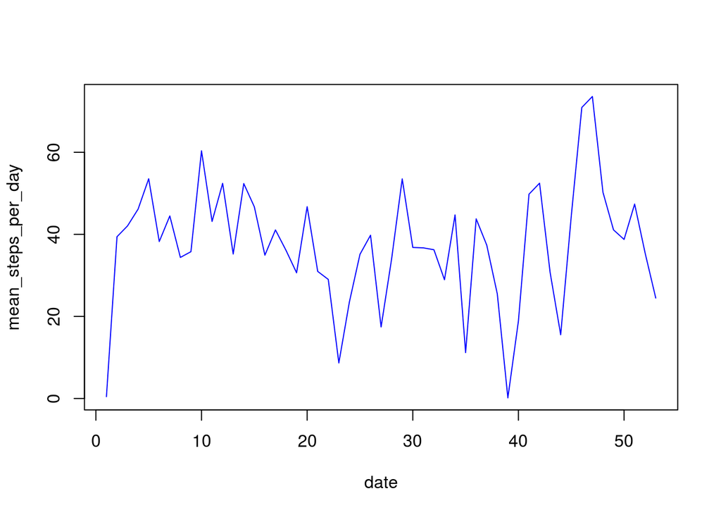

```r
mean_steps_per_day = tapply(data$steps, data$date, mean)
plot(mean_steps_per_day, type="l", col="blue", xlab="date")
```

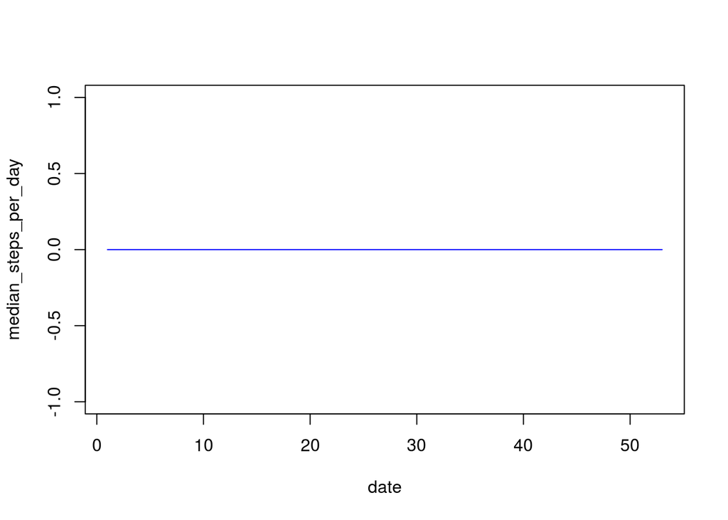

```r
median_steps_per_day = tapply(data$steps, data$date, median)
plot(median_steps_per_day,type="l", col="blue", xlab="date")
```

We calculate the sum of steps per day and plot the histogram:

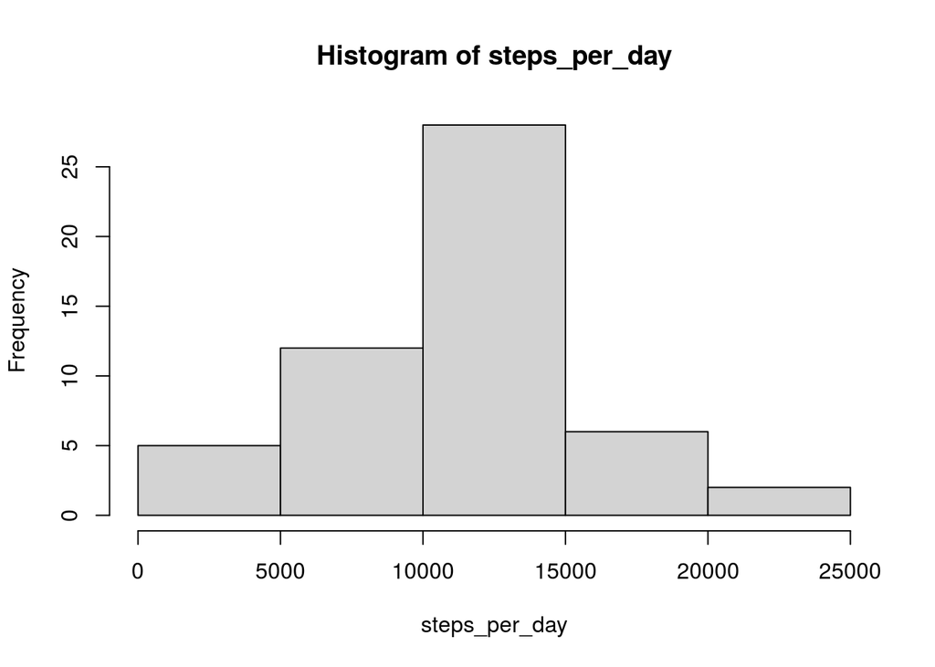

```r
steps_per_day = tapply(data$steps, data$date, sum)
hist(steps_per_day)
```

## What is the average daily activity pattern?

We calculate the average steps over all days for each 5 min interval:

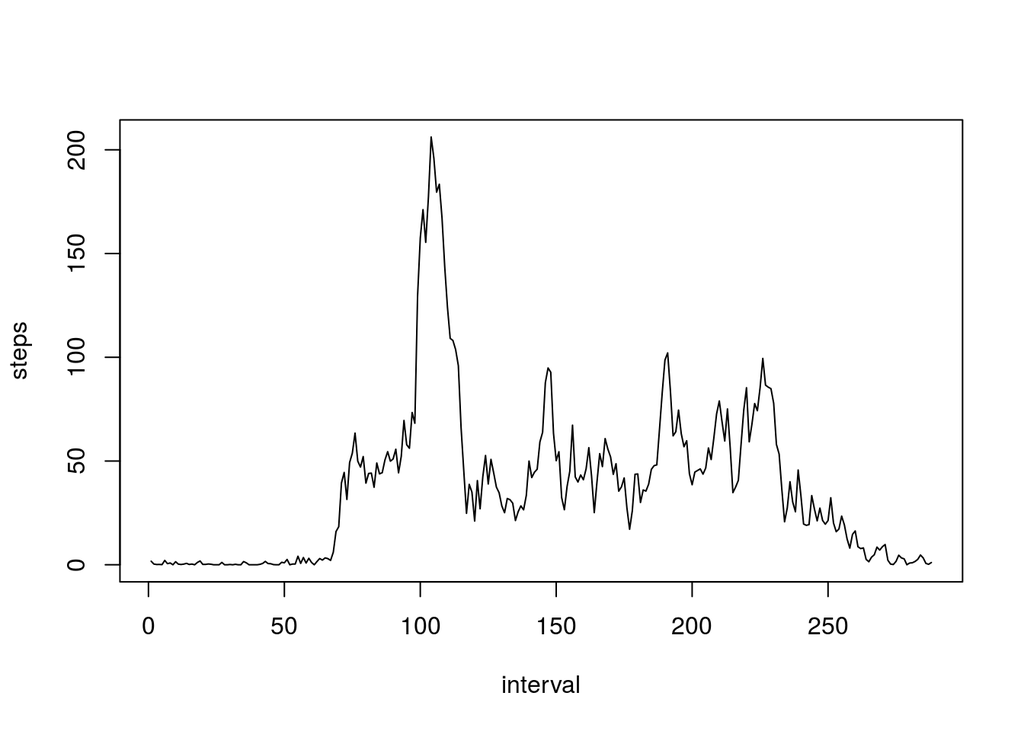

```r
mean_steps_per_interval = tapply(data$steps, data$interval, mean)
plot(mean_steps_per_interval, type="l", xlab="interval", ylab="steps")
```

The interval with the maximum steps is *835*

```r
which.max(mean_steps_per_interval)
```

```
## 835
## 104
```

## Imputing missing values

We reload the data and calculate the number of missing values:

```r
newdata = read.csv("activity.csv", header=T)
sum(is.na(newdata$steps))
```

```
## [1] 2304
```

The number of missing values is: 2304.

We use a silly strategy that consists on replacing NAs with zeros:

```r
newdata[is.na(newdata$steps),"steps"] = 0
```

We compare the mean steps curve per day for the data with 0s instead of NAs and the data without NAs:

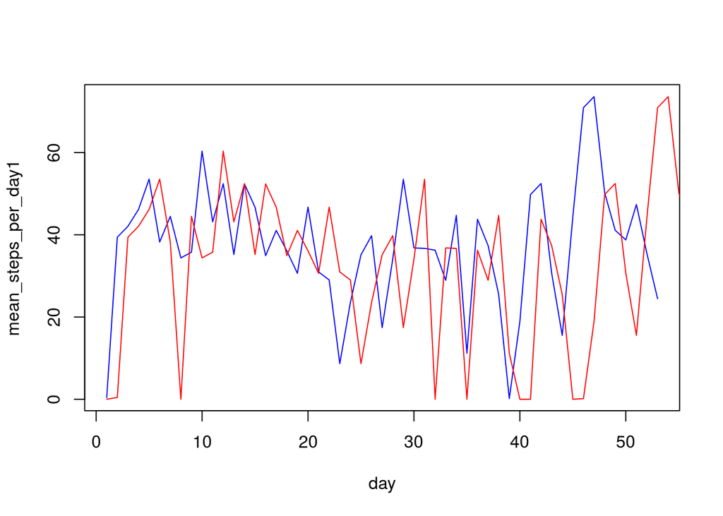

```r
mean_steps_per_day1 = tapply(data$steps, data$date, mean)
mean_steps_per_day2 = tapply(newdata$steps, newdata$date, mean)

plot(mean_steps_per_day1, type="l", col="blue", xlab="day")
lines(mean_steps_per_day2, type="l", col="red", xlab="day")
```

Imputing missing values can give difference results.

## Are there differences in activity patterns between weekdays and weekends?

We create a new factor variable in the dataset with two levels, “weekday” and “weekend”:

```r
data$date = as.Date(data$date, "%Y-%m-%d")

fct = function(x) {
  if (weekdays(x) %in% c("Saturday", "Sunday")) {
    "weekend"
  } else {
    "weekday"
  }
}

data$daytype = sapply(data$date, fct)
```

We plot the average steps per day type:

```r
data_weekday = data[data$daytype == "weekday",]
data_weekend = data[data$daytype == "weekend",]


mean_steps_per_weekday = tapply(data_weekday$steps, data_weekday$interval, mean)
mean_steps_per_weekend = tapply(data_weekend$steps, data_weekend$interval, mean)


length(mean_steps_per_weekend)
```

```
## [1] 288
```

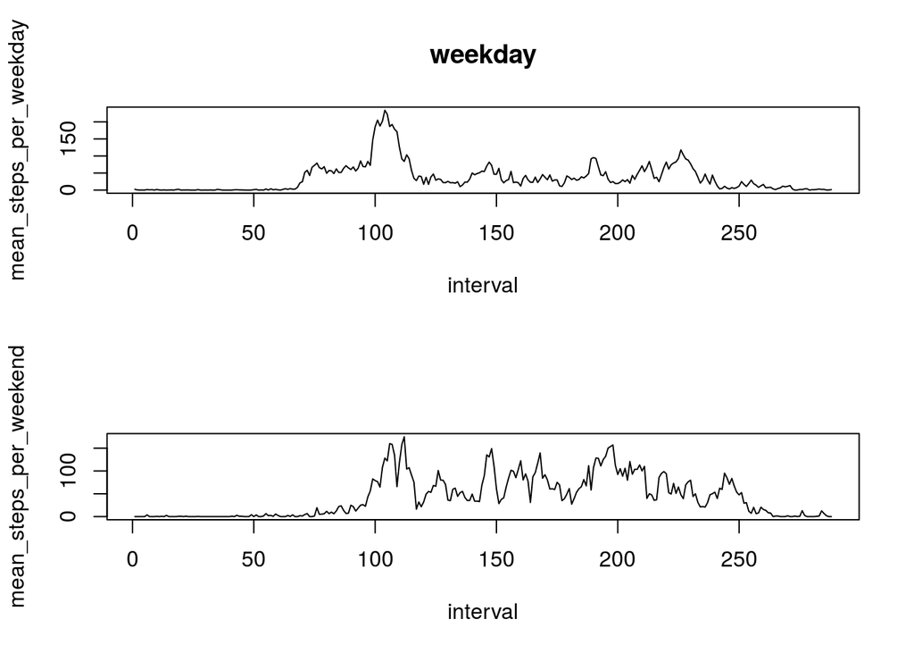

```r
par(mfrow=c(2,1))
plot(mean_steps_per_weekday, type="l",xlab="interval", main="weekday")
plot(mean_steps_per_weekend, type="l", xlab="interval", title="weekend")
```